# openPoland

Kamil Wais

Wed Sep 24 09:34:40 2014

# openPoland

Kamil Wais  
http://www.wais.kamil.rzeszow.pl/openpoland

An R package for communication with `OpenPoland.net API` - a gate to open data in Poland

## Description

With this package you can easily access more than 130 000 000 records in more than 1300 datasets generated in institutions like Central Statistical Office of Poland. The access to open data is available via openData.net API.

## Installing the package

### Stable version from CRAN

Not yet, but this is the goal. Please see below for code that let you install the package from GitHub.

### Developer version from GitHub

Remember to install `devtools` package first!

```r
# install.packages('devtools')
auth_token = 'bfce48a2c16ed7eb4505f9143efaa1e238160443'
devtools::install_github("kalimu/openPoland", auth_token=auth_token)
```

## Registering for a token

You need to have a token to get an authorized acces do openPoland database via API. To get a token you need only to register at https://openpoland.net/signup/.

```r
token = [your_token_here_as_a_character_string]
```

## Example usage

Remember to set Polish locallization before working with dataset titles (they have Polish diacritics)!

```r
Sys.setlocale("LC_ALL", "Polish")
```

```
## [1] "LC_COLLATE=Polish_Poland.1250;LC_CTYPE=Polish_Poland.1250;LC_MONETARY=Polish_Poland.1250;LC_NUMERIC=C;LC_TIME=Polish_Poland.1250"
```

Loading openPoland R package

```r
library(openPoland)
```

Let’s say, we are interested in protected species (“zwierzęta chronione”) in Poland. So we are trying to search for appropriate dataset for our analysis.  
Let’s search

```r
openPolandSearch(query = "zwierz")
```

```
##
 Downloaded pages: 1
##  Done!
##  19 datasets found from the query: 'zwierz'.
```

```
##       id
##  1: 1879
##  2: 1914
##  3: 2097
##  4: 2100
##  5: 2118
##  6: 2071
##  7: 2088
##  8: 3033
##  9: 3028
## 10: 3035
## 11: 3037
## 12: 3029
## 13: 1981
## 14: 2307
```

[output cut: 25 more lines]

```r
openPolandSearch(query = "zwierz", subQuery = "chro")
```

```
##
 Downloaded pages: 1
##  Done!
##  19 datasets found from the query: 'zwierz'.
```

```
##      id                                             title
## 1: 1981 Ważniejsze zwierzęta chronione (NTS-2, 2003-2012)
```

```r
id = 1981
```

That’s it! There is one dataset that have title “Ważniejsze zwierzęta chronione” which means “The most important protected species”. The dataset has an id 1981. Let’s see what are meta information inside.

```r
openPolandMeta(id =  1981, token = token)
```

```
##
## Dataset id: 1981
## Dataset title: Ważniejsze zwierzęta chronione (NTS-2, 2003-2012)
##
## Years: 2003 2004 2005 2006 2007 2008 2009 2010 2011 2012
##
## Zwierzęta
##     id         name
## 1 4212        żubry
## 2 4213       kozice
## 3 4214 niedźwiedzie
## 4 4215        bobry
## 5 4216        rysie
## 6 4217        wilki
```

We can see that we have date for years since 2003 to 2012. NTS-2 means that we have data for regions of Poland and for vivodships. We also have 6 species in our dataset. Let’s suppose that we are interested in total number of animals from proteted species in Poland changing over the years.

First we loading the whole dataset and some additional packages for data manipulation and visualization.

```r
data = openPolandData(id =  1981, token = token)
```

```
##
 Downloaded pages: 1
 Downloaded pages: 2
 Downloaded pages: 3
##  Done!
```

```r
library(dplyr)
```

```r
library(ggplot2)
```

Let’s see how the number of beavers (“bobry”) changes over the year…

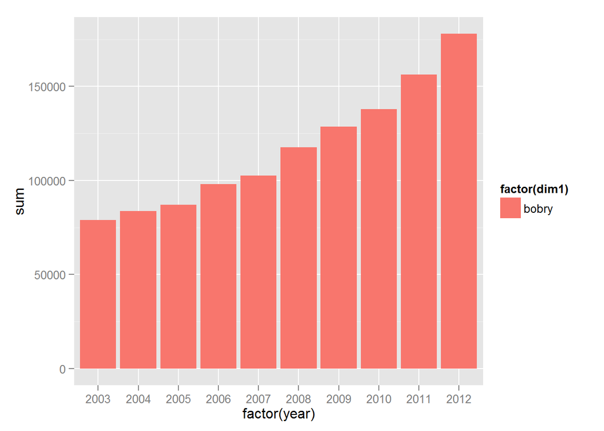

```r
tab =
        as.data.frame(data) %>%
        group_by('year', 'dim1')%.% summarize(sum=sum(value)) %>%
        filter(dim1 %in% c("bobry"))

ggplot(tab,aes(x=factor(year),y=sum, fill = factor(dim1))) +
geom_bar(stat="identity",position="dodge")
```

Than bears (“niedźwiedzie”), moutain goats (“kozice”) and lynxes (“rysie”)…

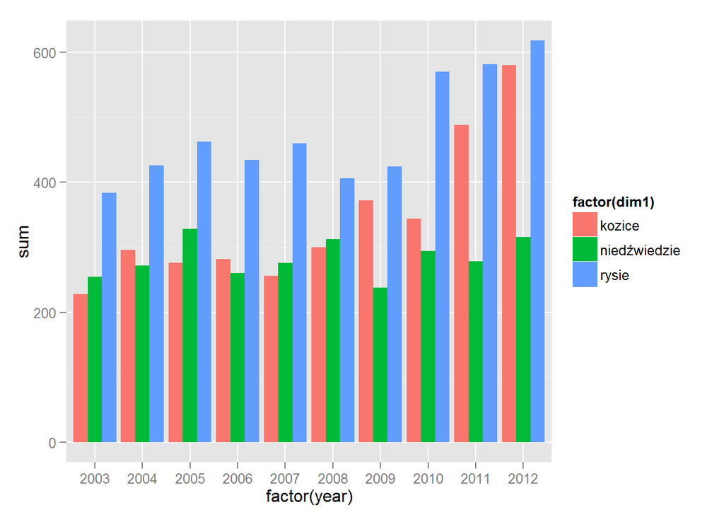

```r
tab =
        as.data.frame(data) %>%
        group_by('year', 'dim1')%.% summarize(sum=sum(value)) %>%
        filter(dim1 %in% c("niedźwiedzie","kozice", "rysie"))

ggplot(tab,aes(x=factor(year),y=sum, fill = factor(dim1))) +
geom_bar(stat="identity",position="dodge")
```

And wolves (“wilki”) and aurochs (“żubry”)…

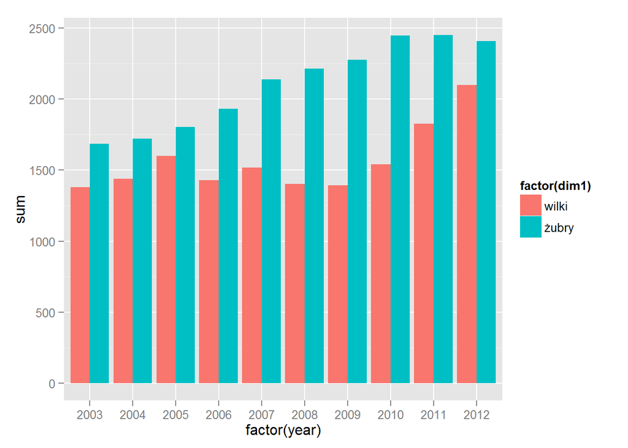

```r
tab =
        as.data.frame(data) %>%
        group_by('year', 'dim1')%.% summarize(sum=sum(value)) %>%
        filter(dim1 %in% c("wilki", "żubry"))

ggplot(tab,aes(x=factor(year),y=sum, fill = factor(dim1))) +
geom_bar(stat="identity",position="dodge")
```

That’s all. You can try yourself.